# Week 6, Day 3

```r
library(tidyverse)
library(janitor)
library(infer)
```

## MVP

### Q1.

Load the data again, clean_names(), and re-familiarise yourself with it.

```r
ames <- read_csv("data/ames.csv") %>% clean_names()
```

```r
glimpse(ames)
```

```
Rows: 2,930
Columns: 82
$ order           <dbl> 1, 2, 3, 4, 5, 6, 7, 8, 9, 10, 11, 12, 13, 14, 15, 16, 17, 18…
$ pid             <dbl> 526301100, 526350040, 526351010, 526353030, 527105010, 527105…
$ ms_sub_class    <dbl> 20, 20, 20, 20, 60, 60, 120, 120, 120, 60, 60, 20, 60, 20, 12…
$ ms_zoning       <chr> "RL", "RH", "RL", "RL", "RL", "RL", "RL", "RL", "RL", "RL", "…
$ lot_frontage    <dbl> 141, 80, 81, 93, 74, 78, 41, 43, 39, 60, 75, NA, 63, 85, NA, …
$ lot_area        <dbl> 31770, 11622, 14267, 11160, 13830, 9978, 4920, 5005, 5389, 75…
$ street          <chr> "Pave", "Pave", "Pave", "Pave", "Pave", "Pave", "Pave", "Pave…
$ alley           <chr> NA, NA, NA, NA, NA, NA, NA, NA, NA, NA, NA, NA, NA, NA, NA, N…
$ lot_shape       <chr> "IR1", "Reg", "IR1", "Reg", "IR1", "IR1", "Reg", "IR1", "IR1"…
$ land_contour    <chr> "Lvl", "Lvl", "Lvl", "Lvl", "Lvl", "Lvl", "Lvl", "HLS", "Lvl"…
$ utilities       <chr> "AllPub", "AllPub", "AllPub", "AllPub", "AllPub", "AllPub", "…
$ lot_config      <chr> "Corner", "Inside", "Corner", "Corner", "Inside", "Inside", "…
$ land_slope      <chr> "Gtl", "Gtl", "Gtl", "Gtl", "Gtl", "Gtl", "Gtl", "Gtl", "Gtl"…
```

[output cut: 69 more lines]

### Q2.

Investigate the distribution of lot_area. Is the distribution roughly normal? If not, what problems do you find?

The distribution is not roughly normal as there is a significant peak and there also look to be right-sided outliers suggesting it is positively skewed.

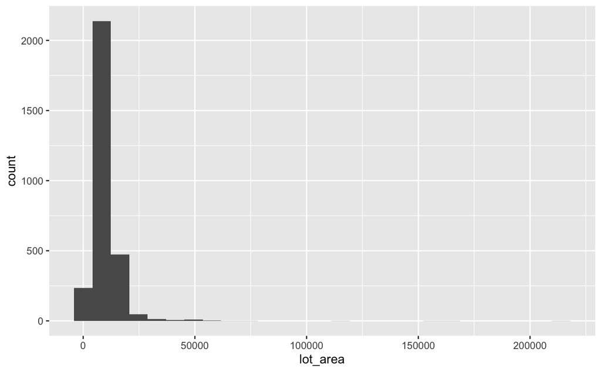

```r
ames %>%
  ggplot() +
  geom_histogram(aes(x = lot_area), bins = 27)
```

### Q3.

Compute and visualise a bootstrap sampling distribution for the mean(lot_area) of the sold houses.

```r
ames_infer_resample_2930 <- ames %>%
  specify(response = lot_area) %>%
  generate(reps = 1000, type = "bootstrap") %>%
  calculate(stat = "mean")

ames_infer_resample_2930
```

```
Response: lot_area (numeric)
```

| replicate | stat |
| --- | --- |
| 1 | 10063.700 |
| 2 | 10162.927 |
| 3 | 10172.442 |
| 4 | 10079.204 |
| 5 | 10121.083 |
| 6 | 10086.026 |
| 7 | 10104.997 |
| 8 | 10459.103 |
| 9 | 10200.006 |
| 10 | 10144.715 |

[output cut: 990 more lines]

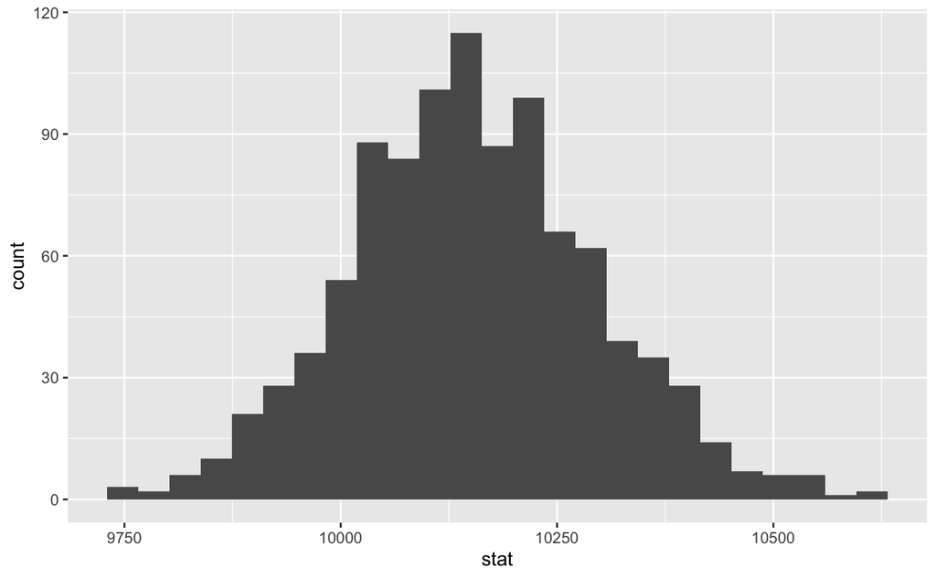

```r
ames_infer_resample_2930 %>%
  ggplot() +
  geom_histogram(aes(x = stat), bins = 25)
```

### Q4.

Use your bootstrap distribution to calculate a 95% CI for mean(lot_area), and visualise it on the distribution.

[output not shown]

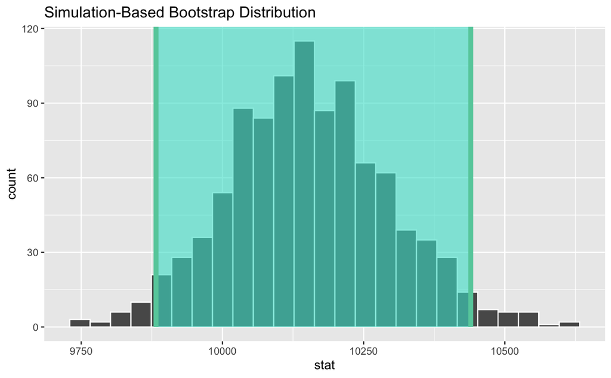

```r
ames_infer_resample_2930 %>%
  visualise(bins = 25) +
  shade_confidence_interval(endpoints = infer_ci_95)
```

### Q5.

You would like to know the mean(lot_area) of the sold houses with higher confidence. Calculate the 99% CI for this variable (you can re-use your bootstrap distribution from above). Is it narrower or broader than the 95% CI? Does that make sense?

It is broader than 95%CI as we need to allow for more possible values in order to increase our confidence.

```r
infer_ci_99 <- ames_infer_resample_2930 %>%
  get_confidence_interval(level = 0.99, type = "percentile")

infer_ci_99
```

| lower_ci | upper_ci |
| --- | --- |
| 9807.824 | 10530.11 |

```r
NA
```

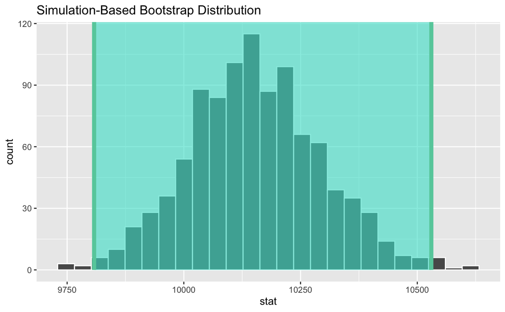

```r
ames_infer_resample_2930 %>%
  visualise(bins = 25) +
  shade_confidence_interval(endpoints = infer_ci_99)
```

### Q6.

Calculate the point estimate of the mean(lot_area)

The point estimate of the mean(lot_area) is 10153.5. In this case if we take our original data `ames` to be the population and calculate the mean(lot_area) we get a value of 10147.92. Here we can see that although these values are slightly different, our point estimate would have fallen within our 95% CI.

```r
mean_infer <- ames_infer_resample_2930 %>%
  summarise(mean = mean(stat))

mean_infer
```

| mean |
| --- |
| 10153.5 |

```r
NA
```

```r
ames %>%
  summarise(mean = mean(lot_area))
```

| mean |
| --- |
| 10147.92 |

```r
NA
```